# Maximum Likelihood and Generalized Linear Models

## Linear models

How should we model outcomes that are non-continuous?

- The “Time spent on childcare” measured on the American Time Use survey is always a non-negative integer value.
- Responses to a “yes/no” question can be treated as 0 and 1, but they’re still discrete outcomes.
- Responses on a Likert scale might be ordered from 1 to 5, but they’re technically not continuous.

Linear models will typically be a poor fit for this kind of outcome.

## Generalized Linear Models

Generalized Linear Models (GLM) are a way of extending the Linear Modeling framework to fit models with all sorts of distributions.

Every GLM has three components:

1. A specific probability distribution (Y) for the outcome variable. Such as: normal, binomial, poisson, gamma etc.
2. A systematic component ($\eta$) that is a linear function of the independent variables (this looks like a linear model $\eta = \beta_0 + \beta_1X_1 + \beta_2X_2...$)
3. A link function $g$ that transforms the linear component into the expected value on the outcome scale (and that can be inverted to transform the outcome back to the linear scale.)

## Notation note

We’ll use some matrix notation here just to make things a bit more readable. Just note that this:

$$X'\beta$$

Is the same thing as the linear model we’ve been writing:

$$\beta_0 + \beta_1X_1 + \beta_2X_2... =$$

## Linear models and Binary Outcomes

To make the problem more concrete, we can use some recently released polling data from the NORC Civic Health & Elections Project to look at modeling vote choice.

As usual, we’re going to initially ignore the survey weights initially, but we’ll bring those back into the analysis in a bit.

## NORC Data

Respondents were asked a series of questions about financial hardships experienced within the last year.

These were combined to create an additive index of “financial hardship”

| **In the past year, have you done or experienced any of the following?** | Yes |
| --- | --- |
| Lost your job | 9% |
| Decided not to purchase, or decided not to keep paying for, health insurance | 9% |
| Taken on additional hours at work or gotten another job | 19% |
| Delayed or skipped getting any type of health care due to cost | 19% |
| Reduced the amount you save including investments and retirement accounts | 24% |
| Increased credit card debt | 25% |
| Borrowed money to pay bills | 27% |
| Delayed or skipped paying a bill | 28% |
| Cancelled or postponed taking a vacation | 29% |
| Used your savings, investments, or retirement accounts to cover your expenses | 30% |
| Cancelled or postponed major purchases | 34% |
| Cut back spending on essential items | 37% |
| Cut back spending on non-essential items | 51% |

Source: NORC Civic Health & Elections Project 2026

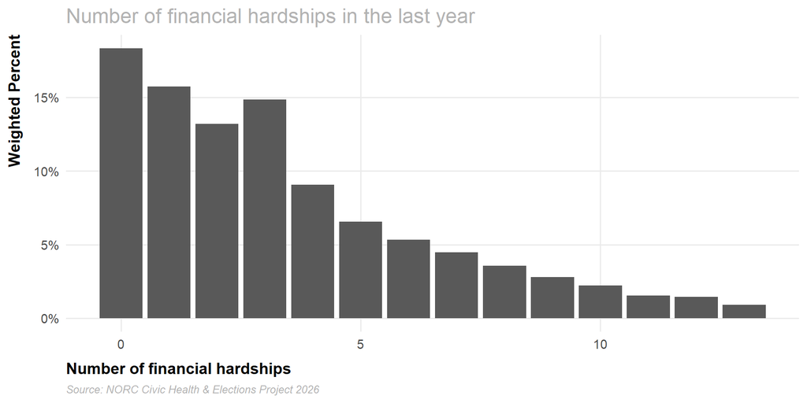

## Modeling a dichotomous outcome

I want to look at the effects of the hardship index on the probability of voting for the Republican candidate in their local congressional race.

I suspect past vote choice may be a confounding variable here, so I also want to control for 2024 vote.

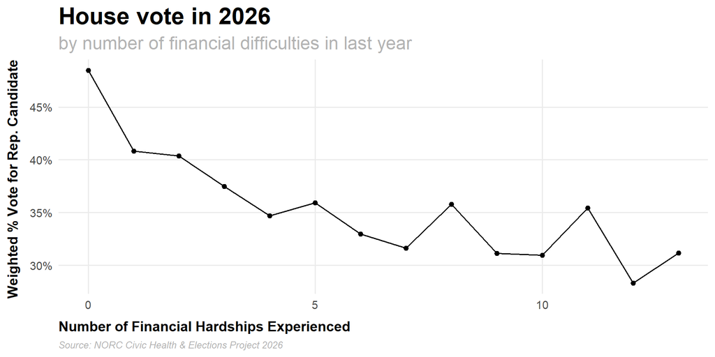

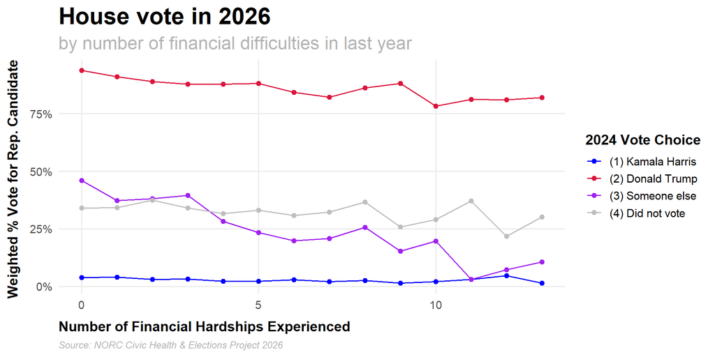

## Modeling a dichotomous outcome

If I convert the yes/no outcome to 1s and 0s, I can still fit a linear model even though the outcome isn’t continuous:

```r
chep_subset$repvote_numeric<-as.numeric(chep_subset$REPVOTE=="Yes")
model<-lm(repvote_numeric ~ HARDSHIP_INDEX + VOTE24_CHOICE,data= chep_subset)
```

## Modeling a dichotomous outcome

The coefficients here can be interpreted as the effect of a one unit increase on each variable on the probability of voting for the Republican in 2026.

- Unformatted Output
- Formatted Output

```
Call:
lm(formula = repvote_numeric ~ HARDSHIP_INDEX + VOTE24_CHOICE,
    data = chep_subset)

Residuals:
     Min       1Q   Median       3Q      Max
-0.89802 -0.05776 -0.01994  0.11711  1.04059

Coefficients:
                                Estimate Std. Error t value Pr(>|t|)
(Intercept)                    0.0577639  0.0020225   28.56   <2e-16 ***
HARDSHIP_INDEX                -0.0075654  0.0003249  -23.28   <2e-16 ***
VOTE24_CHOICE(2) Donald Trump  0.8402519  0.0024323  345.45   <2e-16 ***
VOTE24_CHOICE(3) Someone else  0.2558533  0.0054820   46.67   <2e-16 ***
VOTE24_CHOICE(4) Did not vote  0.3161245  0.0028141  112.34   <2e-16 ***
---
Signif. codes:  0 '***' 0.001 '**' 0.01 '*' 0.05 '.' 0.1 ' ' 1

Residual standard error: 0.3178 on 92674 degrees of freedom
Multiple R-squared:  0.571, Adjusted R-squared:  0.571
F-statistic: 3.084e+04 on 4 and 92674 DF,  p-value: < 2.2e-16
```

|  | 2026 House Vote |
| --- | --- |
| (Intercept) | 0.058 |
|  | [0.054, 0.062] |
| Number of financial difficulties in last year | -0.008 |
|  | [-0.008, -0.007] |
| Did you vote in the 2024 presidential election for Kamala Harris, Donald Trump, or someone else? [(2) Donald Trump] | 0.840 |
|  | [0.835, 0.845] |
| Did you vote in the 2024 presidential election for Kamala Harris, Donald Trump, or someone else? [(3) Someone else] | 0.256 |
|  | [0.245, 0.267] |
| Did you vote in the 2024 presidential election for Kamala Harris, Donald Trump, or someone else? [(4) Did not vote] | 0.316 |
|  | [0.311, 0.322] |
| Num.Obs. | 92679 |

## Modeling a dichotomous outcome

However, the model gives us nonsensical predictions under some conditions:

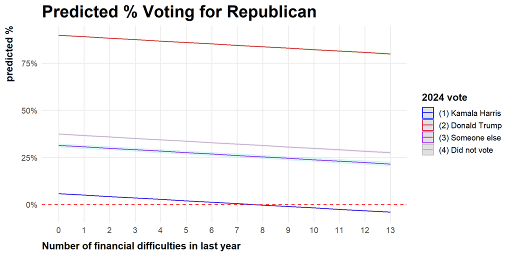

## Modeling a dichotomous outcome

This is the key problem with fitting a linear model to an outcome that isn’t continuous: the outcome here just can’t really be modeled with a line.

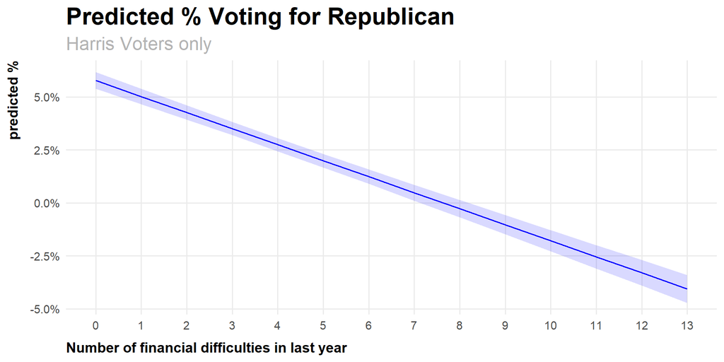

## Generalized Linear Models: dichotomous outcomes

We still want to retain the linear modeling framework $y= X'\beta$, but we need a function that can transform a straight line into something with these properties:

- The function should take any real number as an input and map it onto a 0, 1 range.
- Ideally, we’d like to capture the “diminishing returns” of changes when the probability of y is really high or really low.

[figure not shown]

## Generalized Linear Models: dichotomous outcomes

- The logistic function $p = \frac{1}{1+e^{-(X'\beta)}}$ maps a linear prediction back to the probability scale.
- This amounts to modeling $\log{\frac{p}{1-p}} = \beta ' X$ or the logged odds of y=1.
- This gives us the logit model.

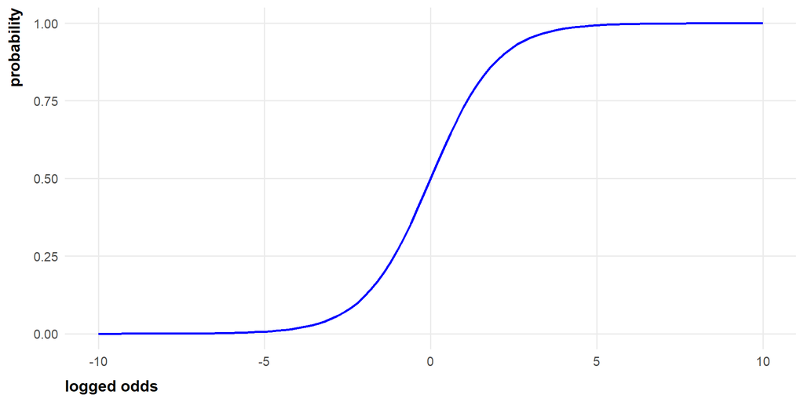

## Generalized Linear Models: dichotomous outcomes

- Another option is to use $\Phi(XB)$ where $\Phi$ is the standard normal cumulative distribution function (the same integral math that turns a z-score into a probability under the normal distribution)
- This gives us the probit model

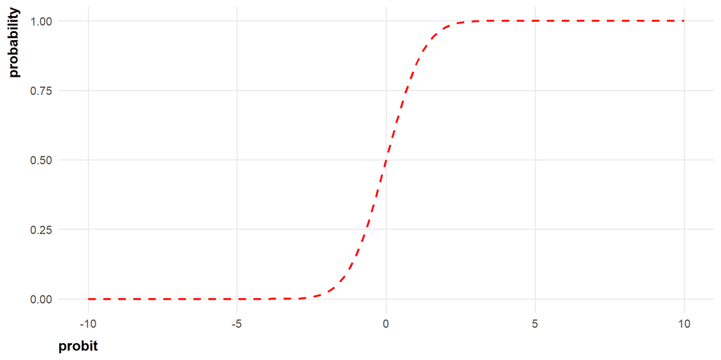

## Logit and probit

- Both the logit and probit models will give us a result that is bounded between 0 and 1.
- The logit model has slightly “fatter tails”, but, in practice, the results tend to be substantively very similar.
- Today, logit models are more common because they have a slightly more intuitive interpretation than probit models.

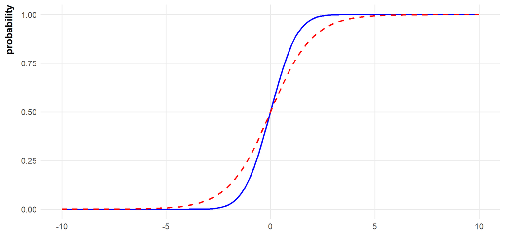

## Generalized Linear Models: dichotomous outcomes

So, now we’ve got everything we need for a generalized linear model:

1. Our outcome has a binomial distribution where everything is a 1 or a 0.
2. We have a systematic component that can be defined with a linear model $\eta= X'B$
3. We have a function (such as logit) that can map $\eta$ onto the response scale.

## Fitting GLMs

In a linear model, we can identify the line of best fit by minimizing the sum of squared residuals, but there’s no real analog for this with a GLM.

So how do I know whether one model is better than any other?

## Fitting GLMs: Maximum Likelihood

- Rather than minimizing the sum of squared errors, most generalized linear models will find the best fit using Maximum Likelihood Estimation (MLE)
- In MLE, we find the set of parameter values (typically denoted using the symbol $\theta$) that are *most likely* to have generated the data we see.

## Fitting GLMs: Maximum Likelihood

We’ll look at a simple application to get a sense of how MLE works: finding the maximum likelihood estimate of a population proportion from a sample proportion.

## MLE of a proportion

- Imagine a survey of 100 randomly selected adults finds that about 26% believe in Bigfoot
- What is the population probability of Bigfoot belief ($\theta$) that is most likely to have generated this result?

## MLE of a proportion

$\theta$ *could* be any number $>0$ and $<1$. It’s *possible* to get a sample where 26% believe in Bigfoot even if the population percent is 40%:

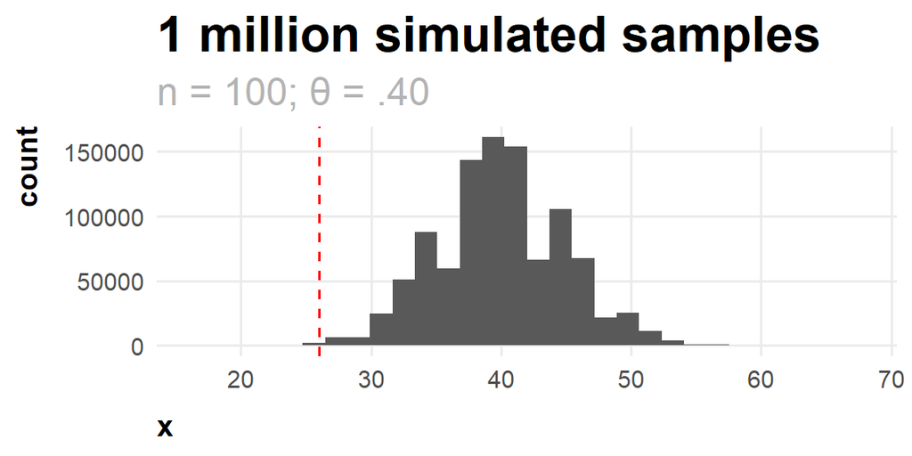

You can probably already guess that the correct answer here is $\theta = .26$, but we want a way to *systematically* pick the best value of $\theta$ for more complicated problems.

## MLE of a proportion

Since “belief in Bigfoot” is a simple yes/no question, then we can model a single response using the Bernoulli Probability Mass Function:

$$\begin{align*}
P(y_i=1|\theta) = \theta^{y_i}(1-\theta)^{1-y_i}\\
\theta = \text{probability that y is 1}\\
y_i = \text{a single response to the question}
\end{align*}$$

So, if $y_i=1$ and $\theta = .20$

$$P(1|.20) = .20^{1}(.75)^{0} = .20$$

If $y_i=0$ and $\theta = .20$

$$P(0|.20) = .20^{0}(.80)^{1} = .80$$

## MLE of a proportion

Assuming that the observations are all independent and identically distributed, we can calculate the *likelihood* of the entire sample by simply multiplying together all the individual probabilities from each of the 100 observations:

$$L(y|\theta) = \prod^n_{i=1} \theta^{y_i}(1-\theta)^{1-y_i} = \theta^{\sum{y_i}}(1-\theta)^{n-\sum{y_i}}$$

## MLE of a proportion

$$L(y|\theta) = \prod^n_{i=1} \theta^{y_i}(1-\theta)^{1-y_i} = \theta^{\sum{y_i}}(1-\theta)^{n-\sum{y_i}}$$

We run into a bit of a computational problem here because we’re multiplying a bunch of probabilities, this gets very small very quickly.

```r
.25 * .25 * .75 * .25 * .25 * .25 * .75 * .25 # ... and so on
```

```
[1] 0.0001373291
```

Using a logarithm gets around this problem by turning the tiny fractions into large negative numbers, and allowing us to use addition rather than multiplication:

```r
log(.25) + log(.25) + log(.75) + log(.25) + log(.25) + log(.25) + log(.75)  + log(.25)
```

```
[1] -8.89313
```

And we can always exponentiate to turn a log likelihood back to a likelihood:

```r
exp(-8.89313)
```

```
[1] 0.0001373291
```

## MLE of a proportion

$$\theta^{\sum{y_i}}(1-\theta)^{n-\sum{y_i}}$$

Taking the log here turns the multiplication into addition, and the exponentiation into multiplication:

$$\log L(y|\theta) = (\sum^n_{i=1}y_i) \log(\theta) + (n-\sum^n_{i=1}{y_i}) \log(1-\theta)$$

## MLE of a proportion

So now we have a function we can use to distinguish good guesses at $\theta$ from bad guesses: we just want to find a parameter that maximizes this function:

$$\log L(y|\theta) = (\sum^n_{i=1}y_i) \log(\theta) + (n-\sum^n_{i=1}{y_i}) \log(1-\theta)$$

```r
# 100 responses with p = .26
y<-rep(c(0, 1), c(74, 26))
ll_prop<-function(y, theta){
  n<-length(y)
  sumy<-sum(y)
  ll<-sumy * log(theta) + (n-sumy) * log(1-theta)
  return(ll)
}


ll_prop(y, .5)
```

```
[1] -69.31472
```

```r
ll_prop(y, .4)
```

```
[1] -61.62466
```

```r
ll_prop(y, .8)
```

```
[1] -124.9001
```

## MLE of a proportion

Again, we could probably just eyeball this, but to find it mathematically we would need to do a bit of calculus:

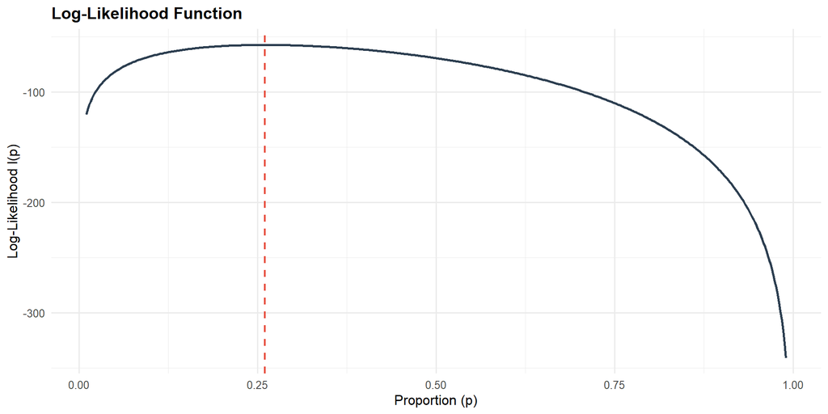

## MLE of a proportion

The maximum is the point where the derivative (slope) of this line with respect to $\theta$ is 0 (and where the second derivative of this line is negative)

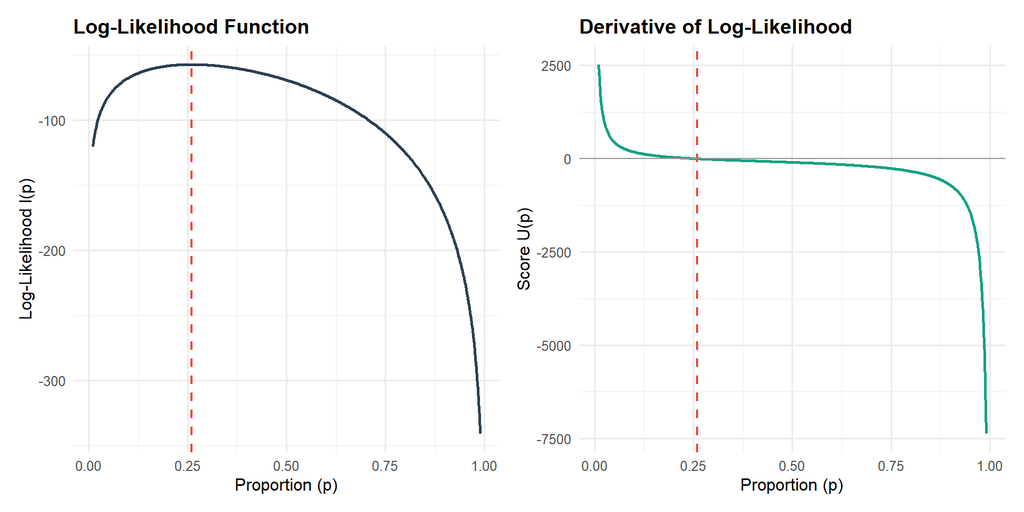

## MLE of a proportion

The maximum is the point where the derivative (slope) of this line with respect to $\theta$ is 0 (and where the second derivative of this line is negative)

$$\log L(y|\theta) = (\sum^n_{i=1}y_i) \log(\theta) + (n-\sum^n_{i=1}{y_i}) \log(1-\theta)$$

## MLE of a proportion

Simplifying the notation a bit…

$$\begin{align*}
&Y \log(\theta) + (n-Y) \log(1-\theta)\\
\end{align*}$$

where $Y = \sum^n_{i=1}{y_i}$

Applying the [chain rule](https://en.wikipedia.org/wiki/Chain_rule)

$$Y \frac{1}{\theta} + (n-Y) \frac{-1}{1-\theta}$$

And simplifying…

## MLE of a proportion

Now we can set it to zero and solve algebraically for $\theta$

$$\begin{align}
\frac{Y}{\theta} = \frac{(n-Y) }{1-\theta} && \text{Adding } \frac{(n-Y) }{1-\theta} \text{ to both sides} \\
Y(1-\theta) =(n-Y)\theta && \text{cross multiplying by } \theta(1-\theta)\\
Y-Y\theta = n\theta - Y\theta && \text{Expanding}\\
Y = n\theta && \text{Cancelling } -Y\theta\\
\theta = \frac{Y}{n} && \text{Solving for } \theta
\end{align}$$

## MLE of a proportion

What is the population probability of Bigfoot belief ($\theta$) that is most likely to have generated a sample with 26% Bigfoot believers?

The estimate of $\theta$ that maximizes the likelihood of observing our data is just the sample proportion: .26!

$$\begin{align*}
\hat{\theta} = \frac{Y}{n} \\
\end{align*}$$

## MLE with a model

The answer in this example was kind of obvious to begin with, but Maximum Likelihood Estimation is useful because it gives us a flexible way to judge models when we can’t rely on an easy metric like the sum of squared errors.

For instance, $\theta$ could be a set of coefficient values in a regression instead of a single average:

$$\begin{align*}
L(y|\theta, X) = \prod^n_{i=1} p ^{y_i} (1-p)^{1-y_i} \\
p = \frac{1}{1+e^{-(\theta'X)}}
\end{align*}$$

We’ve definitely made the problem here more complex, but the goal is the same: we want to find parameters for $\theta$ that maximize the likelihood of our observed data.

## MLE with a model

So, with a simple dataset of 10 observations, we need to come up with two parameter values ($\beta_0$ and $\beta_1$) that maximize the likelihood of the data.

$$\begin{align*}
L(y|\theta, X) = \prod^n_{i=1} p ^{y_i} (1-p)^{1-y_i} \\
p = \frac{1}{1+e^{-(\theta'X)}}
\end{align*}$$

| id | x | y |
| --- | --- | --- |
| 1 | -2.5 | 0 |
| 2 | -1.8 | 0 |
| 3 | -1.2 | 0 |
| 4 | -0.5 | 0 |
| 5 | -0.1 | 1 |
| 6 | 0.4 | 0 |
| 7 | 0.9 | 1 |
| 8 | 1.6 | 1 |
| 9 | 2.2 | 1 |
| 10 | 3.0 | 1 |

## MLE with a model

| id | x | y |
| --- | --- | --- |
| 1 | -2.5 | 0 |
| 2 | -1.8 | 0 |
| 3 | -1.2 | 0 |
| 4 | -0.5 | 0 |
| 5 | -0.1 | 1 |
| 6 | 0.4 | 0 |
| 7 | 0.9 | 1 |
| 8 | 1.6 | 1 |
| 9 | 2.2 | 1 |
| 10 | 3.0 | 1 |

## MLE with a model

- We can do this same calculation separately for each row with our chosen parameters, and then add up all the log likelihoods to get the logged likelihood under this model.
- The log likelihood is -3.4063.

| id | x | y | probability = 1 / (1 + e⁻⁽ᵝ₀ ⁺ ᵝ₁ˣ⁾) | Likelihood = pʸⁱ (1-p)¹⁻ʸⁱ | Log Likelihood |
| --- | --- | --- | --- | --- | --- |
| 1 | -2.5 | 0 | 0.018 | 0.982 | -0.0182 |
| 2 | -1.8 | 0 | 0.069 | 0.931 | -0.0715 |
| 3 | -1.2 | 0 | 0.198 | 0.802 | -0.2206 |
| 4 | -0.5 | 0 | 0.500 | 0.500 | -0.6931 |
| 5 | -0.1 | 1 | 0.690 | 0.690 | -0.3711 |
| 6 | 0.4 | 0 | 0.858 | 0.142 | -1.9519 |
| 7 | 0.9 | 1 | 0.943 | 0.943 | -0.0587 |
| 8 | 1.6 | 1 | 0.985 | 0.985 | -0.0151 |
| 9 | 2.2 | 1 | 0.996 | 0.996 | -0.0040 |
| 10 | 3.0 | 1 | 0.999 | 0.999 | -0.0010 |

## MLE with a model

What if we use $\beta_0 = 1$ and $\beta_1 = 1$?

| id | x | y |
| --- | --- | --- |
| 1 | -2.5 | 0 |
| 2 | -1.8 | 0 |
| 3 | -1.2 | 0 |
| 4 | -0.5 | 0 |
| 5 | -0.1 | 1 |
| 6 | 0.4 | 0 |
| 7 | 0.9 | 1 |
| 8 | 1.6 | 1 |
| 9 | 2.2 | 1 |
| 10 | 3.0 | 1 |

## MLE with a model

What if we use $\beta_0 = 1$ and $\beta_1 = 1$?

The new log likelihood is slightly worse: -4.3721.

| id | x | y | probability = 1 / (1 + e⁻⁽ᵝ₀ ⁺ ᵝ₁ˣ⁾) | Likelihood = pʸⁱ (1-p)¹⁻ʸⁱ | Log Likelihood |
| --- | --- | --- | --- | --- | --- |
| 1 | -2.5 | 0 | 0.182 | 0.818 | -0.2009 |
| 2 | -1.8 | 0 | 0.310 | 0.690 | -0.3711 |
| 3 | -1.2 | 0 | 0.450 | 0.550 | -0.5978 |
| 4 | -0.5 | 0 | 0.622 | 0.378 | -0.9729 |
| 5 | -0.1 | 1 | 0.711 | 0.711 | -0.3411 |
| 6 | 0.4 | 0 | 0.802 | 0.198 | -1.6195 |
| 7 | 0.9 | 1 | 0.870 | 0.870 | -0.1393 |
| 8 | 1.6 | 1 | 0.931 | 0.931 | -0.0715 |
| 9 | 2.2 | 1 | 0.961 | 0.961 | -0.0398 |
| 10 | 3.0 | 1 | 0.982 | 0.982 | -0.0182 |

## Trying out some parameters

[interactive chart not shown]

Log Likelihood:

[interactive chart not shown]

## MLE with a model

So how do we find the right parameters here without guesswork?

$$\begin{align*}
L(y|\theta, X) = \prod^n_{i=1} p ^{y_i} (1-p)^{1-y_i} \\
p = \frac{1}{1+e^{-(\theta'X)}}
\end{align*}$$

Just like the previous case, we would find the (partial) derivative of the log likelihood function with respect to each parameter, set to zero, and solve:

$$\frac{\partial\ell}{\partial\beta_1} = \sum{^n_{i=1}}\left( y_i-\frac{1}{1+e^{-(\beta_0 +\beta_1X_i)}} \right) X$$

## MLE with a model

However, unlike the previous case, **we can’t solve this algebraically**, so the parameters here are approximated using a numeric algorithm (R’s GLM function uses [iteratively reweighted least squares](https://en.wikipedia.org/wiki/Iteratively_reweighted_least_squares))

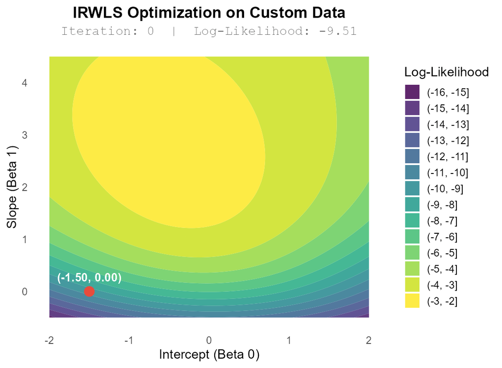

## Back where we started

```r
lm(repvote_numeric ~ HARDSHIP_INDEX + VOTE24_CHOICE,data= chep_subset)
```

The formula syntax remains the same, but the use the `glm` function and we specify a logit link with `family=binomial(link='logit')`

```r
glm(repvote_numeric ~ HARDSHIP_INDEX + VOTE24_CHOICE,data= chep_subset,
    family=binomial(link='logit'))
```

Or the probit link with `family=binomial(link='probit')`

```r
glm(repvote_numeric ~ HARDSHIP_INDEX + VOTE24_CHOICE,data= chep_subset,
    family=binomial(link='probit'))
```

## Back where we started: logit model

- Unlike a linear model, GLM coefficients typically lack a straightforward interpretation.
- In the case of the logit model, each coefficient represents the effect of a one unit increase in that variable on the logged odds ratio: $\log \left( \frac{p}{1-p}\right)$
- On this scale, positive values correspond to an increasing probability, and negative values mean decreasing probability, but there’s less that can be said beyond this.

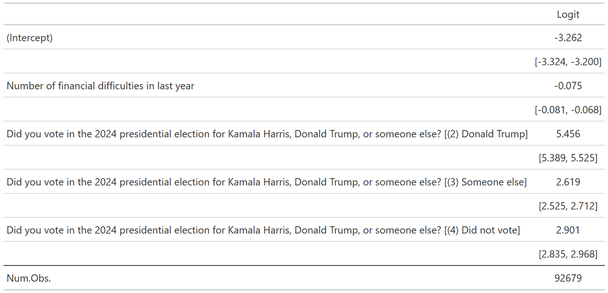

## Back where we started: logit model

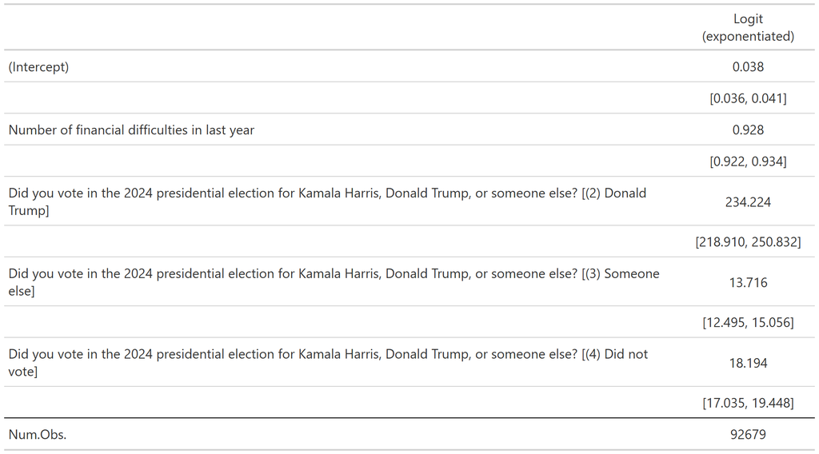

## Logit probabilities

- We can also transform logit regression values back into predicted probabilities.
- To do this, we would first get a linear prediction for a particular scenario and then transform it back into a probability using the logistic function: $\frac{1}{1+e^{-(\beta_0 + \beta_1x_1 + \beta_2x_2...)}}$

## Logit probabilities

For instance: what is the probability of a Republican House vote for someone with 3 financial hardships who voted for Trump in 2024?

Start by getting the linear prediction:

$$\begin{aligned}
\eta &= -3.25\ - \\
&\quad 0.07(3)\ + \\
&\quad 5.42(1)\ + \\
&\quad 2.53(0)\ + \\
&\quad 2.86(0) \\
= 1.96
\end{aligned}$$

Then transform it using the logistic function:

The model predicts an 88% chance of voting Republican.

## Logit probabilities

Notice here that the effects of HARDSHIP_INDEX, on the probability scale, are not constant. They get slightly stronger as we move toward P=.5

| VOTE24_CHOICE | HARDSHIP_INDEX | Prediction | Change from previous |
| --- | --- | --- | --- |
| (2) Donald Trump | 0 | 0.900 | NA |
| (2) Donald Trump | 1 | 0.893 | -0.007 |
| (2) Donald Trump | 2 | 0.885 | -0.008 |
| (2) Donald Trump | 3 | 0.878 | -0.007 |
| (2) Donald Trump | 4 | 0.869 | -0.009 |
| (2) Donald Trump | 5 | 0.861 | -0.008 |
| (2) Donald Trump | 6 | 0.851 | -0.010 |
| (2) Donald Trump | 7 | 0.842 | -0.009 |
| (2) Donald Trump | 8 | 0.832 | -0.010 |
| (2) Donald Trump | 9 | 0.821 | -0.011 |
| (2) Donald Trump | 10 | 0.810 | -0.011 |
| (2) Donald Trump | 11 | 0.798 | -0.012 |
| (2) Donald Trump | 12 | 0.785 | -0.013 |
| (2) Donald Trump | 13 | 0.773 | -0.012 |

## Back where we started: logit model

Ideally, we would like to be able to interpret the effects in terms of probabilities, but the effect of each variable on the probability scale is not linear. In the next class, we’ll talk about some ways to handle this, as well as how to assess models and use other types of GLMs.

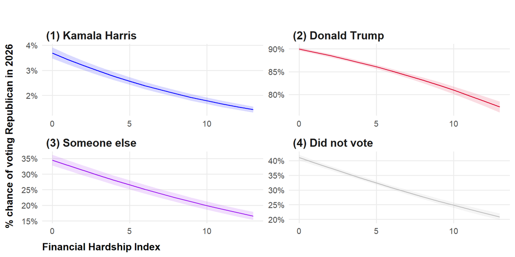

## R-code

If you’re interested in playing around with NORC’s Civic Health Poll, you can access the whole file using the code below:

```r
library(tidyverse)
library(haven)
fname<-here::here("Data", "chep.zip")
if(!file.exists(fname)){
  download.file('https://civichealth.norc.org/downloads/civichealth_datafile.zip',
                mode='wb',
                dest=fname
  )
}

chep<-read_dta(unz(fname, filename='civichealth_datafile.dta' ))

# Converting stata formatted variables to factors
chep_fac<-chep|>
  as_factor()

# https://civichealth.norc.org/index.html for more info on the data
```

## R-code

Running the logistic regression on example data:

```r
library(tidyverse)
# downloading a pre-filtered a recoded subset of the CHEP data
file<-url('https://github.com/Neilblund/SDSB340-Fall-2026/raw/refs/heads/master/Data/chep5000.rds')
chep_subset<-readRDS(file)


model<-glm(
  REPVOTE  ~ HARDSHIP_INDEX + VOTE24_CHOICE ,
  family = binomial(link='logit'),
  data = chep_subset)
summary(model)
# getting predictions on the response scale for different values of the predictors:

# 1. create a data frame with combinations of the predictors:
df<-expand.grid(VOTE24_CHOICE = c("(1) Kamala Harris","(2) Donald Trump",
                                  "(3) Someone else", "(4) Did not vote"
                                  ),
               HARDSHIP_INDEX = 0:13)

#2. use predict on the model object with the newdata and type='response' options:
df$prediction<-predict(model,
        newdata= df,
        type='response'
        )

ggplot(df, aes(x=HARDSHIP_INDEX, y=prediction,
               color =VOTE24_CHOICE
               )) + geom_line() +
  scale_y_continuous(labels = scales::label_percent()) +
  labs(y='Probability of voting for Republican',
       x = "Number of financial hardships",
       subtitle = "Number of financial hardships in the last year",
       caption = "Source: NORC Civic Health & Elections Project 2026",
       color = '2024 Presidential Vote'
       ) +
    scale_color_manual(values=c("blue","#DC143C", "purple", "grey"))+
  facet_wrap(~VOTE24_CHOICE, scales='free') +
  guides(color='none')
```